# Foundations of Data Science Project - Diabetes Analysis

## Context

Diabetes is one of the most frequent diseases worldwide and the number of diabetic patients are growing over the years. The main cause of diabetes remains unknown, yet scientists believe that both genetic factors and environmental lifestyle play a major role in diabetes.

A few years ago research was done on a tribe in America which is called the Pima tribe (also known as the Pima Indians). In this tribe, it was found that the ladies are prone to diabetes very early. Several constraints were placed on the selection of these instances from a larger database. In particular, all patients were females at least 21 years old of Pima Indian heritage.

## Objective

Here, we are analyzing different aspects of Diabetes in the Pima Indians tribe by doing Exploratory Data Analysis.

## Data Dictionary

The dataset has the following information:

- Pregnancies: Number of times pregnant
- Glucose: Plasma glucose concentration over 2 hours in an oral glucose tolerance test
- BloodPressure: Diastolic blood pressure (mm Hg)
- SkinThickness: Triceps skin fold thickness (mm)
- Insulin: 2-Hour serum insulin (mu U/ml)
- BMI: Body mass index (weight in kg/(height in m)^2)
- DiabetesPedigreeFunction: A function that scores the likelihood of diabetes based on family history.
- Age: Age in years
- Outcome: Class variable (0: a person is not diabetic or 1: a person is diabetic)

## Q 1: Import the necessary libraries and briefly explain the use of each library (3 Marks)

```python
# Remove _____ & write the appropriate library name

import numpy as np

import pandas as pd

import seaborn as sns

import matplotlib.pyplot as plt

%matplotlib inline
```

#### Write your Answer here:

Ans 1: Numpy: Provides multidimensional arrays and methods to support scientific computing in Python. Pandas: Supports data structures for efficient data processing and analysis. Matplotlib: Charting library, with matplotlib.pyplot making manipulation as easy as in MATLAB. Seaborn: Statistical charting library, integrated with matplotlib and pandas, making data visualization easier.

## Q 2: Read the given dataset (2 Marks)

```python
# Remove _____ & write the appropriate function name

pima = pd.read_csv ("diabetes.csv")
```

## Q3. Show the last 10 records of the dataset. How many columns are there? (2 Marks)

```python
# Remove ______ and write the appropriate number in the function

pima.tail(10)
```

|  | Pregnancies | Glucose | BloodPressure | SkinThickness | Insulin | BMI | DiabetesPedigreeFunction | Age | Outcome |
| --- | --- | --- | --- | --- | --- | --- | --- | --- | --- |
| 758 | 1 | 106 | 76 | 20 | 79 | 37.5 | 0.197 | 26 | 0 |
| 759 | 6 | 190 | 92 | 20 | 79 | 35.5 | 0.278 | 66 | 1 |
| 760 | 2 | 88 | 58 | 26 | 16 | 28.4 | 0.766 | 22 | 0 |
| 761 | 9 | 170 | 74 | 31 | 79 | 44.0 | 0.403 | 43 | 1 |
| 762 | 9 | 89 | 62 | 20 | 79 | 22.5 | 0.142 | 33 | 0 |
| 763 | 10 | 101 | 76 | 48 | 180 | 32.9 | 0.171 | 63 | 0 |
| 764 | 2 | 122 | 70 | 27 | 79 | 36.8 | 0.340 | 27 | 0 |
| 765 | 5 | 121 | 72 | 23 | 112 | 26.2 | 0.245 | 30 | 0 |
| 766 | 1 | 126 | 60 | 20 | 79 | 30.1 | 0.349 | 47 | 1 |
| 767 | 1 | 93 | 70 | 31 | 79 | 30.4 | 0.315 | 23 | 0 |

#### Write your Answer here:

Ans 3:There are 9 columns in this dataset.

## Q4. Show the first 10 records of the dataset (2 Marks)

```python
# Remove _____ & write the appropriate function name and the number of rows to get in the output

pima.head(10)
```

|  | Pregnancies | Glucose | BloodPressure | SkinThickness | Insulin | BMI | DiabetesPedigreeFunction | Age | Outcome |
| --- | --- | --- | --- | --- | --- | --- | --- | --- | --- |
| 0 | 6 | 148 | 72 | 35 | 79 | 33.600000 | 0.627 | 50 | 1 |
| 1 | 1 | 85 | 66 | 29 | 79 | 26.600000 | 0.351 | 31 | 0 |
| 2 | 8 | 183 | 64 | 20 | 79 | 23.300000 | 0.672 | 32 | 1 |
| 3 | 1 | 89 | 66 | 23 | 94 | 28.100000 | 0.167 | 21 | 0 |
| 4 | 0 | 137 | 40 | 35 | 168 | 43.100000 | 2.288 | 33 | 1 |
| 5 | 5 | 116 | 74 | 20 | 79 | 25.600000 | 0.201 | 30 | 0 |
| 6 | 3 | 78 | 50 | 32 | 88 | 31.000000 | 0.248 | 26 | 1 |
| 7 | 10 | 115 | 69 | 20 | 79 | 35.300000 | 0.134 | 29 | 0 |
| 8 | 2 | 197 | 70 | 45 | 543 | 30.500000 | 0.158 | 53 | 1 |
| 9 | 8 | 125 | 96 | 20 | 79 | 31.992578 | 0.232 | 54 | 1 |

## Q5. What do you understand by the dimension of the dataset? Find the dimension of the `pima` dataframe. (3 Marks)

```python
# Remove _____ & write the appropriate function name

pima.shape
```

```
(768, 9)
```

#### Write your Answer here:

Ans 5:The size of a data set is the number of rows and columns it contains. The first element represents the number of rows and the second element represents the number of columns. In this case, there are 768 rows and 9 columns.

## Q6. What do you understand by the size of the dataset? Find the size of the `pima` dataframe. (3 Marks)

```python
# Remove _____ & write the appropriate function name

pima.size
```

```
6912
```

#### Write your Answer here:

Ans 6:The size of a dataset is the total number of elements in the dataset, which is equivalent to the total number of cells in the data frame found by multiplying the number of rows by the number of columns.

## Q7. What are the data types of all the variables in the data set? (2 Marks)

**Hint: Use the info() function to get all the information about the dataset.**

```python
# Remove _____ & write the appropriate function name

pima.info()
```

```
<class 'pandas.core.frame.DataFrame'>
RangeIndex: 768 entries, 0 to 767
Data columns (total 9 columns):
 #   Column                    Non-Null Count  Dtype
---  ------                    --------------  -----
 0   Pregnancies               768 non-null    int64
 1   Glucose                   768 non-null    int64
 2   BloodPressure             768 non-null    int64
 3   SkinThickness             768 non-null    int64
 4   Insulin                   768 non-null    int64
 5   BMI                       768 non-null    float64
 6   DiabetesPedigreeFunction  768 non-null    float64
 7   Age                       768 non-null    int64
 8   Outcome                   768 non-null    int64
dtypes: float64(2), int64(7)
memory usage: 54.1 KB
```

#### Write your Answer here:

Ans 7:The dataset contains two numerical data types: int64 (64-bit integers) and float64 (64-bit floating-point numbers). Both of these represent numerical values, meaning all 9 columns in the dataset are numerical.

## Q8. What do we mean by missing values? Are there any missing values in the `pima` dataframe? (4 Marks)

```python
# Remove _____ & write the appropriate function name

pima.isnull().values.any()
```

```
False
```

#### Write your Answer here:

Ans 8:Missing values are blank cells in the dataframe, indicating that some information is absent from the dataset. Here, the output of False confirms that there are no missing values in the data.

```python
# Remove _____ & write the appropriate function name

pima.iloc[: , 0 : 8].describe()
```

|  | Pregnancies | Glucose | BloodPressure | SkinThickness | Insulin | BMI | DiabetesPedigreeFunction | Age |
| --- | --- | --- | --- | --- | --- | --- | --- | --- |
| count | 768.000000 | 768.000000 | 768.000000 | 768.000000 | 768.000000 | 768.000000 | 768.000000 | 768.000000 |
| mean | 3.845052 | 121.675781 | 72.250000 | 26.447917 | 118.270833 | 32.450805 | 0.471876 | 33.240885 |
| std | 3.369578 | 30.436252 | 12.117203 | 9.733872 | 93.243829 | 6.875374 | 0.331329 | 11.760232 |
| min | 0.000000 | 44.000000 | 24.000000 | 7.000000 | 14.000000 | 18.200000 | 0.078000 | 21.000000 |
| 25% | 1.000000 | 99.750000 | 64.000000 | 20.000000 | 79.000000 | 27.500000 | 0.243750 | 24.000000 |
| 50% | 3.000000 | 117.000000 | 72.000000 | 23.000000 | 79.000000 | 32.000000 | 0.372500 | 29.000000 |
| 75% | 6.000000 | 140.250000 | 80.000000 | 32.000000 | 127.250000 | 36.600000 | 0.626250 | 41.000000 |
| max | 17.000000 | 199.000000 | 122.000000 | 99.000000 | 846.000000 | 67.100000 | 2.420000 | 81.000000 |

## Q 10. Plot the distribution plot for the variable 'BloodPressure'. Write detailed observations from the plot. (2 Marks)

[output not shown]

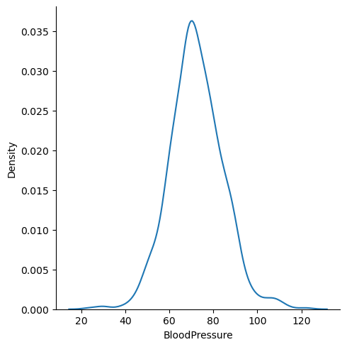

```python
# Remove _____ & write the appropriate library name

sns.displot(pima['BloodPressure'], kind='kde')

plt.show()
```

#### Write your Answer here:

Ans 10:The distribution has a bell shape similar to a normal distribution but with a sharper peak, and looks fairly symmetric. The mean is around 70, and most of the observations lie between 40 and 100.

## Q 11. What is the 'BMI' of the person having the highest 'Glucose'? (2 Marks)

```python
# Remove _____ & write the appropriate function name

pima[pima['Glucose'] == pima['Glucose'].max()]['BMI']
```

```
661    42.9
Name: BMI, dtype: float64
```

#### Write your Answer here:

Ans 11:The BMI of the person with highest glucose is 42.9.

## Q12.

### 12.1 What is the mean of the variable 'BMI'?

### 12.2 What is the median of the variable 'BMI'?

### 12.3 What is the mode of the variable 'BMI'?

### 12.4 Are the three measures of central tendency equal?

### (4 Marks)

```python
# Remove _____ & write the appropriate function name

m1 = pima['BMI'].mean()  # mean
print(m1)

m2 = pima['BMI'].median()  # median
print(m2)

m3 = pima['BMI'].mode()[0]  # mode
print(m3)
```

```
32.45080515543619
32.0
32.0
```

#### Write your Answer here:

Ans 12:The mean, median, and mode of the BMI variable are 32.45, 32, and 32, respectively. Since the mean is approximately equal to the median and mode, this suggests that the data is symmetric.

## Q13. How many women's 'Glucose' levels are above the mean level of 'Glucose'? (2 Marks)

```python
# Remove _____ & write the appropriate function name

pima[pima['Glucose'] > pima['Glucose'].mean()].shape[0]
```

```
343
```

#### Write your Answer here:

Ans 13:There are 343 women which have glucose levels above the glucose mean.

## Q14. How many women have their 'BloodPressure' equal to the median of 'BloodPressure' and their 'BMI' less than the median of 'BMI'? (2 Marks)

```python
# Remove _____ & write the appropriate column name

pima[(pima['BloodPressure'] == pima['BloodPressure'].median()) & (pima['BMI'] < pima['BMI'].median())]
```

|  | Pregnancies | Glucose | BloodPressure | SkinThickness | Insulin | BMI | DiabetesPedigreeFunction | Age | Outcome |
| --- | --- | --- | --- | --- | --- | --- | --- | --- | --- |
| 14 | 5 | 166 | 72 | 19 | 175 | 25.8 | 0.587 | 51 | 1 |
| 93 | 4 | 134 | 72 | 20 | 79 | 23.8 | 0.277 | 60 | 1 |
| 103 | 1 | 81 | 72 | 18 | 40 | 26.6 | 0.283 | 24 | 0 |
| 205 | 5 | 111 | 72 | 28 | 79 | 23.9 | 0.407 | 27 | 0 |
| 299 | 8 | 112 | 72 | 20 | 79 | 23.6 | 0.840 | 58 | 0 |
| 325 | 1 | 157 | 72 | 21 | 168 | 25.6 | 0.123 | 24 | 0 |
| 330 | 8 | 118 | 72 | 19 | 79 | 23.1 | 1.476 | 46 | 0 |
| 366 | 6 | 124 | 72 | 20 | 79 | 27.6 | 0.368 | 29 | 1 |
| 380 | 1 | 107 | 72 | 30 | 82 | 30.8 | 0.821 | 24 | 0 |
| 393 | 4 | 116 | 72 | 12 | 87 | 22.1 | 0.463 | 37 | 0 |
| 406 | 4 | 115 | 72 | 20 | 79 | 28.9 | 0.376 | 46 | 1 |
| 446 | 1 | 100 | 72 | 12 | 70 | 25.3 | 0.658 | 28 | 0 |
| 460 | 9 | 120 | 72 | 22 | 56 | 20.8 | 0.733 | 48 | 0 |
| 488 | 4 | 99 | 72 | 17 | 79 | 25.6 | 0.294 | 28 | 0 |
| 497 | 2 | 81 | 72 | 15 | 76 | 30.1 | 0.547 | 25 | 0 |
| 510 | 12 | 84 | 72 | 31 | 79 | 29.7 | 0.297 | 46 | 1 |
| 568 | 4 | 154 | 72 | 29 | 126 | 31.3 | 0.338 | 37 | 0 |
| 615 | 3 | 106 | 72 | 20 | 79 | 25.8 | 0.207 | 27 | 0 |
| 635 | 13 | 104 | 72 | 20 | 79 | 31.2 | 0.465 | 38 | 1 |
| 644 | 3 | 103 | 72 | 30 | 152 | 27.6 | 0.730 | 27 | 0 |
| 717 | 10 | 94 | 72 | 18 | 79 | 23.1 | 0.595 | 56 | 0 |
| 765 | 5 | 121 | 72 | 23 | 112 | 26.2 | 0.245 | 30 | 0 |

#### Write your Answer here:

```python
pima[(pima['BloodPressure']==pima['BloodPressure'].median()) & (pima['BMI']<pima['BMI'].median())].shape[0]
```

```
22
```

Ans 14:There are 22 women which have a blood pressure equal to the blood pressure median and a BMI less than the BMI median.

[output not shown]

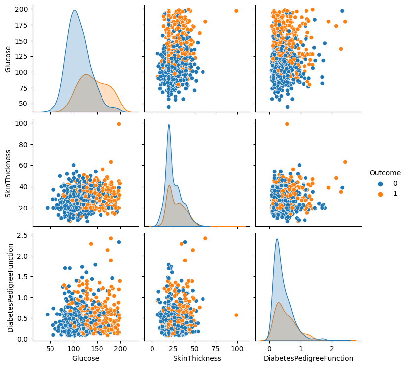

```python
# Remove _____ & write the appropriate function name

sns.pairplot(data = pima, vars = ['Glucose', 'SkinThickness', 'DiabetesPedigreeFunction'], hue = 'Outcome')
plt.show()
```

## Q16. Plot the scatterplot between 'Glucose' and 'Insulin'. Write your observations from the plot. (4 Marks)

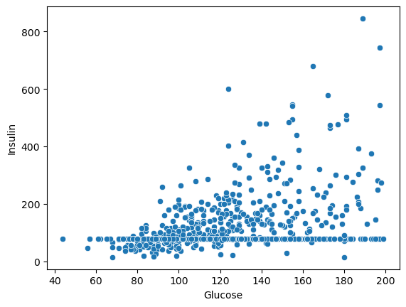

```python
# Remove _____ & write the appropriate function name

sns.scatterplot(x = 'Glucose', y = 'Insulin', data = pima)
plt.show()
```

#### Write your Answer here:

Ans 16:This scatter plot shows us two trends: Insulin and glucose have a positive relationship, meaning that when glucose levels rise, more insulin is produced. The non-diabetic group is most likely the source of these data points. Additionally, a horizontal line indicates that insulin levels remain constant while glucose levels rise. The lack of insulin production in the presence of glucose is explained by the fact that these data points are most likely from the diabetic group.

## Q 17. Plot the boxplot for the 'Age' variable. Are there outliers? (2 Marks)

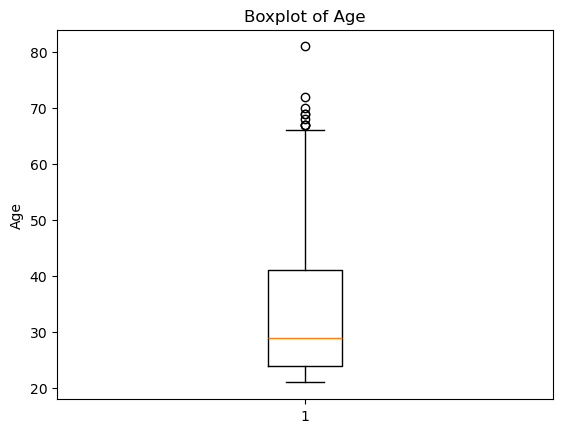

```python
# Remove _____ & write the appropriate function and column name

plt.boxplot(pima['Age'])

plt.title('Boxplot of Age')
plt.ylabel('Age')
plt.show()
```

#### Write your Answer here:

Ans 17:There are a few outliers that lie above the age of 65.

## Q18. Plot histograms for the 'Age' variable to understand the number of women in different age groups given whether they have diabetes or not. Explain both histograms and compare them. (5 Marks)

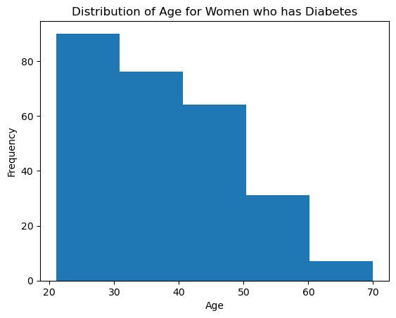

```python
# Remove _____ & write the appropriate function and column name

plt.hist(pima[pima['Outcome'] == 1]['Age'], bins = 5)
plt.title('Distribution of Age for Women who has Diabetes')
plt.xlabel('Age')
plt.ylabel('Frequency')
plt.show()
```

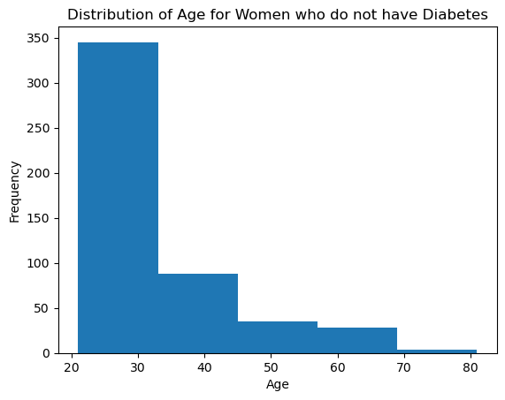

```python
# Remove _____ & write the appropriate function and column name

plt.hist(pima[pima['Outcome'] == 0]['Age'], bins = 5)
plt.title('Distribution of Age for Women who do not have Diabetes')
plt.xlabel('Age')
plt.ylabel('Frequency')
plt.show()
```

#### Write your Answer here:

Ans 18:Diabetes is more common in younger people in our group, according to the first histogram, whereas it is less common in elderly women. In contrast to older age groups, the second histogram displays a similar and more noticeable tendency for non-diabetic individuals, i.e., there are much more women in the 20–30 age range without diabetes. When comparing the two histograms and seeing how their forms vary, the second histogram shows a far larger decline following the 20–30 age bracket. This may suggest that maintaining a healthy weight becomes more difficult as one ages.

## Q 19. What is the Interquartile Range of all the variables? Why is this used? Which plot visualizes the same? (5 Marks)

```python
# Remove _____ & write the appropriate variable name

Q1 = pima.quantile(0.25)
Q3 = pima.quantile(0.75)
IQR = Q3 - Q1
print(IQR)
```

```
Pregnancies                  5.0000
Glucose                     40.5000
BloodPressure               16.0000
SkinThickness               12.0000
Insulin                     48.2500
BMI                          9.1000
DiabetesPedigreeFunction     0.3825
Age                         17.0000
Outcome                      1.0000
dtype: float64
```

#### Write your Answer here:

Ans 19:A metric of dispersion that illustrates how dispersed the data is is the interquartile range. The data is more variable the higher it gets, and vice versa. This can be shown using a box plot, in which the interquartile range is represented by the box's height (if vertical) or width (if horizontal).

```python
# Remove _____ & write the appropriate function name and run the code

corr_matrix = pima.iloc[ : ,0 : 8].corr()
corr_matrix
```

|  | Pregnancies | Glucose | BloodPressure | SkinThickness | Insulin | BMI | DiabetesPedigreeFunction | Age |
| --- | --- | --- | --- | --- | --- | --- | --- | --- |
| Pregnancies | 1.000000 | 0.128022 | 0.208987 | 0.009393 | -0.018780 | 0.021546 | -0.033523 | 0.544341 |
| Glucose | 0.128022 | 1.000000 | 0.219765 | 0.158060 | 0.396137 | 0.231464 | 0.137158 | 0.266673 |
| BloodPressure | 0.208987 | 0.219765 | 1.000000 | 0.130403 | 0.010492 | 0.281222 | 0.000471 | 0.326791 |
| SkinThickness | 0.009393 | 0.158060 | 0.130403 | 1.000000 | 0.245410 | 0.532552 | 0.157196 | 0.020582 |
| Insulin | -0.018780 | 0.396137 | 0.010492 | 0.245410 | 1.000000 | 0.189919 | 0.158243 | 0.037676 |
| BMI | 0.021546 | 0.231464 | 0.281222 | 0.532552 | 0.189919 | 1.000000 | 0.153508 | 0.025748 |
| DiabetesPedigreeFunction | -0.033523 | 0.137158 | 0.000471 | 0.157196 | 0.158243 | 0.153508 | 1.000000 | 0.033561 |
| Age | 0.544341 | 0.266673 | 0.326791 | 0.020582 | 0.037676 | 0.025748 | 0.033561 | 1.000000 |

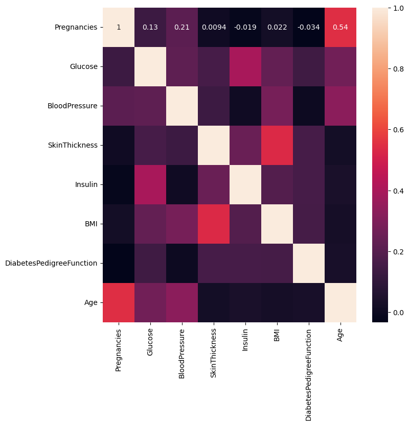

```python
# Remove _____ & write the appropriate function name

plt.figure(figsize = (8, 8))
sns.heatmap(corr_matrix, annot = True)

# Display the plot
plt.show()
```